# Network approach for understanding small-scale fisheries governance: The case of the Chilean coastal co-management system - ScienceDirect

## [Marine Policy](https://www.sciencedirect.com/journal/marine-policy)

[Volume 34, Issue 5](https://www.sciencedirect.com/journal/marine-policy/vol/34/issue/5), September 2010, Pages 851-858

# Network approach for understanding small-scale fisheries governance: The case of the Chilean coastal co-management system

, [Fikret Berkes <sup>2</sup>](https://www.sciencedirect.com/author/7003357893/fikret-berkes)

https://doi.org/10.1016/j.marpol.2010.01.007[Get rights and content](https://s100.copyright.com/AppDispatchServlet?publisherName=ELS&contentID=S0308597X10000084&orderBeanReset=true)

Full text access

## Abstract

Recent studies have focused on the study of social networks among local resource users, but few have attempted to study co-management networks. The objective of the research was to assess the Chilean shellfish co-management system from an organizational network perspective. Starting with one detailed case study, representatives of 38 small-scale fisher associations from two administrative regions were interviewed to investigate: (1) networks of actors in each co-management case, (2) the functions of these actors in co-management, and (3) fisher perceptions about Chile's co-management arrangement. Results indicate that decision-making is highly centralized and power is concentrated in government, with little horizontal exchange and cooperation among fisher associations. However, the network approach indicates the presence of a rich set of players, some seven sets of actors by function. Grassroots management innovations are hampered by the existing co-management structure, suggesting that the system may benefit from a modification of the policy to allow greater learning-by-doing and flexibility.

## Keywords

Networks

Co-management

Benthic resources

Governance

Small-scale fishery

Chile

## 1. Introduction

Conventional top-down resource management is often blind to users’ social, economic, and cultural conditions. Co-management, or the sharing of power and responsibility between the government and local resource users, is a way to deal with the limitations of a single agency, top-down approach. In fisheries management, there is increasing interest in co-management as a way to involve fishers and other actors in governance [1], [2]. At the same time, it is widely recognized that co-management does not have a single, universally accepted definition, and that it refers to a range of arrangements with different degrees of power sharing. A large literature indicates that it is futile to seek “blueprint” solutions to co-management. Complexity and dynamics of social-ecological systems and, for example, the history of cooperation itself in a particular case, will have a strong impact on the co-management outcome [3]. Different social and ecological conditions, and different administrative and legal arrangements create a range of possibilities within which co-management may or may not work. It is of interest, therefore, to learn from particular experiences to improve co-management iteratively and adaptively [4].

Along with accumulating experience, theoretical approaches to natural resources co-management have evolved to give better account of the complexity and dynamics of social-ecological systems. Conceptualizations of co-management have moved from depicting it as a two-party arrangement, with a unitary state and a homogeneous local community of users, towards more inclusive characterizations with multiple actors from all sectors at different scales [5], [6]. Researchers have questioned the focus on formal policy-driven structures, instead concentrating on the functional side of co-management as real-life, practical partnerships [7]. In a sense, the idea and practice of co-management as a power-sharing institution have progressively moved from a governmental and hierarchical model to a governance model and a network paradigm. Such a view regards multiple linkages and social relationships as the very nature of co-management [7].

If co-management is a form of governance that extends beyond the realm of the state, and governance is comprised of multiple and complex social networks, then how do these co-management networks function? How can these networks can be approached and measured? The aim of this paper is to explore, based on empirical data, the potentials of the network approach to the study of small-scale fisheries governance, using the Chilean coastal co-management case. We use Social Network Analysis [8] and a two-mode network approach [9] to investigate the distribution of power and influence by means of the network *degree* centrality measurement. Strengths and weaknesses of the system are discussed by integrating qualitative information into the analysis. We provide more detail on the approach and study methods following some background on Chilean co-management.

## 2. The Chilean system: management and exploitation areas for benthic resources

In the late 1980s, the small-scale fishery sector in Chile went through a profound crisis. The most important shellfish resource in this sector, the *loco* (*Concholepas concholepas*), a gastropod often marketed as “Chilean abalone”, showed alarming overexploitation as a consequence of an open-access regime [10]. The problem was characterized by social and economic instability, the emergence of a black market, and the risk of commercial extinction [11], [12]. In response to the crisis, government authorities imposed a four-year (1989-92) total harvest ban. In 1991, the Fisheries and Aquaculture Law provided a new framework for the establishment of Management and Exploitation Areas for Benthic Resources (MEABR) [11]. The law recognized the right of organized artisanal fishers to regulate common-property territorial use rights in these management areas (MAs), to harvest *loco* and other resources [13], [14].

The fishery covered in this study is a subset of the small-scale fishery sector and excludes the pelagic fishery. The zone under co-management is a collection of MAs along a 5 mile coastal strip reserved for the artisanal fishery. To put the MEABR system under perspective, only 18.5% of the total artisanal catch is shellfish, and of that only 2% are benthic resources that come under co-management [15]. The system has evolved over the years. Under the present system, formal fisher organizations<sup>3</sup> (locally called *caletas*, or coves) sign a four-year renewable agreement with the state. The contract must be grounded on a baseline resource assessment and a resource management plan prepared by biological consultants hired by fishers. A number of economically valuable shellfish, crustaceans, and seaweed species come under this system of territorial use rights and co-management [12], [13], [14], [16].

The implementation of MEABR as formal public policy started in 1997. Its rapid expansion and the preliminary social and economic outcomes, and the biological recovery of *loco* and other resources, suggested a successful and promising model of resource co-management [10], [14], [16], [17], [18], [19]. Nonetheless, having achieved a certain degree of success in the first ten years or so, there has been an emergence of new and complex problems, such as unsatisfactory economic outcomes from managed harvests, and user complaints concerning top-down management [18], [19]. Based on international experience, this is not surprising. There are always challenges in stakeholder relationships and governance; co-management is a process and not an end-point [7], [20].

The MEABR system is set up in law as a “triumvirate” of fisher associations, state institutions, and technical assistance institutions [21]. However, a “triumvirate” may be a rather limited view of the actual diversity of the players and the complexity of the co-management system. Some recent research has identified the participation of a significant number of individuals (e.g., within each community) and organizations (e.g., different unions, the state at the national and regional levels, scientists and consultants, and middlemen) around co-management [12], [14], [19]. This suggests the existence of complex networks in Chilean co-management – networks that have not been studied systematically.

## 3. Methods

The basic idea of SNA – the formal study of social relationships and the social structure – is that individuals, groups, and organizations interact and form relatively stable social structures or networks [8]. These networks mobilize valuable resources and information which are relevant for human action and development. In recent years, natural resource management scholars have paid increasing attention to SNA concepts and methods [22], [23], [24], [25]. Bodin and his coauthors [25] for instance, explored likely consequences of network *centrality*, *density*, and *betweenness* on social memory, trust, and learning in adaptive co-management systems. Most of this literature has focused on the implications of different patterns of social relationships *among* resource users. In SNA terminology, the design of such research relies on *one-mode* networks [26]. The actors included have in essence the same nature (e.g., fishers) and their interactions are represented in a squared (*n*×*n*) matrix<sup>4</sup>.

However, the governance of fisheries, and certainly also other resources, relies on complex interactions among diverse sectors, and the *one-mode* network approach is likely to be inadequate. If all actors were equal, one could assess the relationships among fishers, between fishers and traders, and between the state and scientists on the same basis. But this is not the case; hence a more suitable approach requires the possibility of studying more than one subset of actors at the same time. That is the case of *two-mode* networks, based on rectangular (*n* × *m*) datasets<sup>5</sup> [8]. Here, the latter approach is adopted and fisher organizations are depicted as the focal actors of co-management networks, as illustrated in Table 1.

Table 1. Two-mode network matrix of fisher organizations and co-management counterparts<sup>a</sup>.

| Empty Cell | Empty Cell | Co-management counterparts A | Co-management counterparts B | Co-management counterparts C | Co-management counterparts … (*N*=28) | Co-management counterparts Others |
| --- | --- | --- | --- | --- | --- | --- |
| Fisher organizations | FO1 | 1 | 0 | 0 | 1 | 0 |
|  | FO2 | 0 | 1 | 1 | 0 | 0 |
|  | … | 1 | 0 | 1 | 0 | 0 |
|  | … | 0 | 0 | 0 | 0 | 1 |
|  | FO38 | 0 | 1 | 1 | 0 | 0 |

**a**

For facilitating and hindering relationships 1= existent relationship and 0= non-existent relationship.

The study covered two non-adjacent administrative regions of Chile: The V Region of Valparaiso, which is the centre of national fisheries policy-making and represents 1.1% of the co-managed national shellfish catch (from 58 MAs); and the VIII Region of Bio-bio with 14.7% of the national benthic harvest (from 139 MAs). Data collection methods included: (1) participant observation and workshops with one fisher group (*Caleta* Montemar in the Valparaiso region); (2) semi-structured questionnaires applied to 38 fisher leaders; and (3) in-depth interviews with fishers, fisher leaders, public officials, scholars, and private sector representatives.

The elected leaders/representatives of 38 fisher organizations in two regions of Chile were surveyed to learn about the linkages they have to other actors with respect to co-management. The presidents were selected as they are the “gatekeepers” of co-management and the links between fishers and the organizational environment. A roster of 28 “co-management counterparts” was used in the questionnaire including<sup>6</sup>: (1) co-managers in terms of policy (e.g., fisheries authorities and fisher organizations), (2) other public and private institutions (e.g., public agencies, consultancies, and businesses), and (3) fisher associations at higher scales (e.g., federations and confederations). Properly speaking, these co-management actors are not real individual entities but social roles or categories [26] that were previously identified as being involved in the co-management system.

## 4. Key actors of co-management: facilitating and hindering roles

Drawing on the valence of relationships, two networks can be derived: the network of facilitating and the network of hindering relationships. The assumption is that real-life co-management, involving dynamic power-sharing and problem-solving processes, implies an interplay of collaborative and conflictive networks with multiple actors. In this study, the facilitating network registered 410 actual relationships, and the hindering network 130. In other words, the network of facilitating relationships is much denser than that of hindering. The results suggest that even though both conflictive and collaborative actors are present, there is an overall prominence of facilitating relationships in the MEABR co-management system.

However, in terms of the individual co-management counterparts, a number of actors had both facilitating and hindering relationships. A more careful examination of these two facets is presented based on network centrality analysis. The *degree* is a measure of network centrality that reflects the relative prominence of focal points within the network, based on the level of connecting activity [9], [26], [29]. For two-mode networks, *degree* refers to each actor's total number of linkages, expressed as a fraction of the maximum number of possible linkages<sup>8</sup> [9], [26]. In this case, variation in *degree* indicates which counterparts are more connected and thus play more central roles in the system, from the overall standpoint of fisher leaders. *Degree* becomes an attribute of the actors involved in the network that is based on the relationships among them.

Fig. 1 presents the results of all the facilitating and hindering relationships among all the parties (or counterparts) of co-management in the two study areas. The difference between the bars representing facilitating and hindering relationships is the “net facilitating” *degree* of a given counterpart. Thus, the figure shows, for example, that regional federations have the highest net facilitating *degree* and very low hindering *degree*. By contrast, large industries that cause resource degradation (such as mining, pulp, and power production) show hindering *degree* that exceeds their facilitating *degree*, with an overall net negative facilitating *degree*. The counterparts with the highest net facilitating degrees include universities (that provide a number of technical services). By contrast, *caletas* do not seem to show a net facilitating degree for one another. The case of near *caletas* (adjoining or neighbouring co-management areas) is worth mentioning: facilitating and hindering *degrees* are nearly equal, and consequently their net facilitating *degree* is neutral. The various actors are ranked according to their net facilitating degree, providing the basis for the identification of key roles, both positive and negative, of all the counterparts in the MEABR system.

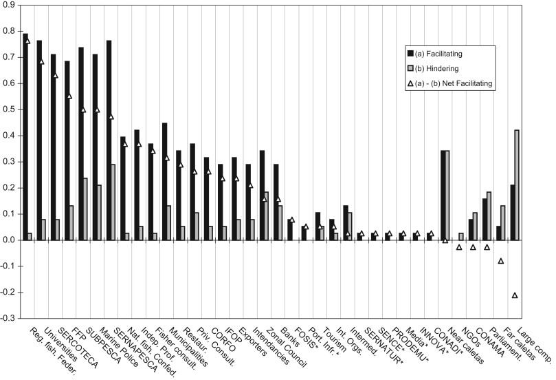

1. [Download: Download full-size image](https://ars.els-cdn.com/content/image/1-s2.0-S0308597X10000084-gr1.jpg)

Fig. 1. Degree centrality of co-management counterparts in the MEABR system. Legend: <sup>⁎</sup> = actors that were not in the orogonal roster but were added by the informants.

Three major breakpoints visually apparent in the ranking in Fig. 1 indicate the existence of four centrality groups in the overall network. Table 2 provides the net degree ranges of the four groups, and the number of actors that fall within each. First, the group on the far left shows the highest levels of net facilitating *degree* (≥ 0.474), and includes regional federations, universities, SERCOTEC, FFPA, SUBPESCA, the Marine Police, and SERNAPESCA (a list of acronyms can be found in the Appendix A). Second is a group that has lesser net facilitating centrality (⩽0.368, ≥0.158) but includes a larger number of agents, such as national confederations, municipalities, CORFO, and banks. Third is a group of actors with decreasing net facilitating centrality (⩽0.079) and presumably much lower prominence in the co-management system as a whole, such as FOSIS, international organizations, and the media. Finally, at the right side of the graph, six actors have zero or negative balance of *degree* centrality, namely near *caletas*, NGOs, CONAMA, parliamentarians, far *caletas,* and polluting industries. According to aggregated fisher leaders’ perceptions, the overall contribution of these actors to co-management is negative; any positive contributions they may have is equalled or exceeded by the obstacles they represent.

Table 2. Net facilitating centrality groups of co-management counterparts.

| Empty Cell | Net degree range | No. of actors |
| --- | --- | --- |
| High | ≥0.474 | 7 |
| Mid | 0.158≥*x*≤0.368 | 12 |
| Low | 0.026>*x*≤0.079 | 11 |
| Negative | ≤0 | 6 |

Within each group, the actors share similar net facilitating centrality, but they come from heterogeneous sectors. The diverse kinds of institutions within each group (e.g., state, civil society, and private sector) and the variety of functions they play in co-management (e.g., rights allocation, expert knowledge, and marketing) suggest that no single sector dominates the entire co-management network. Actors facilitate or hinder the development of co-management in different ways, and consequently the connections of fishers with those actors are also qualitatively different. The paper now proceeds to look at co-management tasks or functions to understand the complexities of co-management governance.

## 5. Power and centrality in multiple interacting governance networks

Seven functional groups in co-management were identified: fisher associations; power-sharing and enforcement (government); funding (mostly government); territorial authorities (various levels of government); monitoring, research and development; marketing; and “other” (private sector and civil society). Actors were grouped according to their contributions in these seven functional groups. The network so produced is presented in Fig. 2. The size of the symbols expresses the net facilitating *degree* of actors, as discussed in Section 4. The figure indicates that:

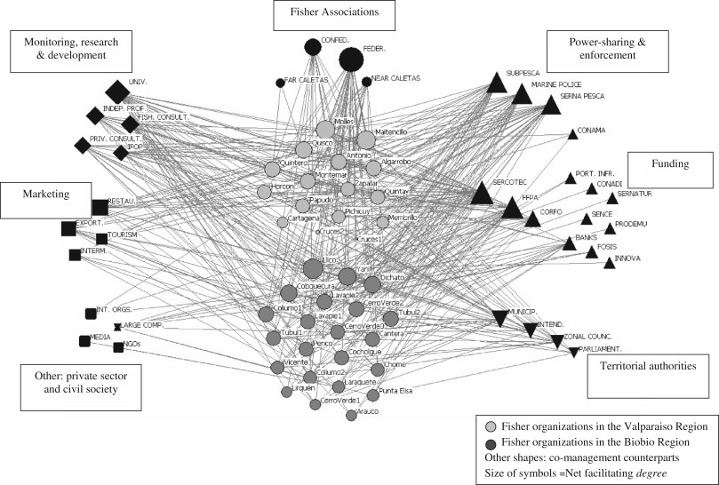

1. [Download: Download full-size image](https://ars.els-cdn.com/content/image/1-s2.0-S0308597X10000084-gr2.jpg)

Fig. 2. Interplaying functional networks of the MEABR co-management system.

- •

  The web of connections tends to be much denser on the right-hand side where all the various state institutions are situated. This highlights the central importance of the state and the power held by government agencies within the MEABR co-management network.
- •

  On the left-hand side of the figure, predominantly involving private and civil society sectors, the thicker web of collaborative links is directed towards technical assistance institutions or knowledge producers. The latter stresses the prominence of expert knowledge for the functioning of the system as required by policy.
- •

  In the center of the figure under Fisher Associations, the black circles express internal cross-scale linkages within the fisheries sector. At the top of the figure, a dense set of linkages is directed towards regional federations, followed by linkages with national confederations. The centrality of these fisher associations indicates the importance of self-organizing efforts to represent fishers’ interests and to counterbalance the influence of other actors, other private users of coastal ecosystems, and the state. Note that near and far *caletas* show relatively weak linkages among themselves.
- •

The clusters presented in Fig. 2 are not always independent of one another because of multifunctionality. Rather, co-management can be seen as the dynamic interplay between these multiple functional networks. In fact, most of the challenges and opportunities emerge from matches and mismatches among the functional groups and the actors involved. For example, fishers consider the bureaucracy involved in permit renewals, and in setting allowable catch levels and harvest deadlines, hinders their ability to respond to market opportunities, prompting them to call for more autonomy and secure harvest rights. Opportunities include aquaculture joint ventures, with fishers pooling aquaculture concessions, local knowledge, and labour, and companies providing investment, expertise, and technology.

## 6. Strengths and weaknesses of the co-management system

Based on empirical evidence, a number of strengths and weaknesses of the MEABR co-management system can be identified. Chilean co-management is characterized by mostly positive interactions. It is supported by facilitating relationships among fisher organizations and their counterparts, starting with new legislation in 1991. The MEABR system resulted in the recovery of *loco* and other benthic resources, and has built a collaborative platform for governance. The system can be seen as consisting of multiple and diversified networks formed to satisfy multiple functions of co-management, such as power-sharing, funding, monitoring, and the coordination of trade<sup>9</sup>. Furthermore, in terms of the sectors involved, results show that co-management includes much more than a monolithic state and a group of homogeneous users. It includes a broad set of public agencies, private organizations, fisher associations, and civil society organizations. In fact, the extended list of actors, who play different roles in the system, presents a much more complex set of relationships than suggested by formal policy and captured in Schumann's “triumvirate” (fishery authorities, biologists, and fishers) [21].

Regional fisher federations, a product of fisher self-organization, appeared as the central actor in the network of co-management, and are the most influential fisher organizations in the small-scale fisheries sector. As umbrella organizations, regional federations represent potential meeting points for the many individual fisher organizations involved in co-management. As bridging organizations [20], federations represent the connection between the local level and regional and national fisheries authorities. They stand out as key players in the overall small-scale sector, linking local demands of fishers with the action of national confederations. The role of federations and confederations is to counterbalance the pervasive power of the state and the influence of other resource and ecosystem users. As such, they represent a fundamental driver of policy change.

The analysis showed positive recognition of the role played by institutions providing expert knowledge to the management system, and also highlighted the differences in fisher perceptions about these institutions. The MEABR policy established the requirement that resource exploitation by fishers had to be monitored by technical assistance institutions, including universities, private consultants, and the semi-public IFOP. Nonetheless, growing interest from fishers for increased participation in stock assessments (and thereby reduce consultancy costs) and to enhance the productivity of MAs is reflected in the overall high centrality of university counterparts. Drawn from several long-term fisher-university partnerships, fishers are demanding more resources and support. The question here is not whether technical assistance institutions should or should not participate in the functioning of MAs, but rather the kind of assistance that is provided and the cost [21]. Experts fostering resource enhancement measures and active management schemes are regarded by fishers as relatively more positive participants in co-management. Similarly, technical teams created by fisher associations themselves were identified in the study as an emerging actor that provides committed support to fisher co-managers.

The analysis also highlights several weaknesses of Chilean co-management system. These include the high degree of centralization; economic problems experienced by fishers; conflicts and hindering relationships within the system; and conflicts with industries that impact marine resources negatively. The top-down nature of MEABR co-management has been noted by several researchers [13], [18], [19]. The centrality of state institutions can also be seen as a positive factor in co-management. The stability of the state and the rule of law provide a solid base for actors and the management system. However, when considering the specific functions performed by fisheries authorities, it becomes obvious that key enabling decisions are centered on public agencies. The combination of bureaucracy and the rigidity of the law define a state-driven system with little room for bottom-up learning and innovation.

Even though the overall system appeared mostly collaborative, conflicts among actors still exist. Conflicts or hindering relationships were identified by fisher leaders with many organizations from different sectors. The high level of hindering relationships with near and far *caletas* can be explained by the threat of mutual poaching from MAs<sup>10</sup>. Illegal extraction from MAs still exists and has been regarded as one of the main obstacles to co-management in Chile [30]. Questions arise about the effectiveness of enforcement and policing mechanisms and the kind of sanctions established, and also the scale of co-management and the implicit incentives or disincentives for fishers to implement more effective social control mechanisms among themselves.

Conflicts over poaching are related to the low level of positive horizontal linkages among fisher organizations. This situation may have hampered social processes to improve and enhance co-management through social learning. For example, fisher organizations have the potential to learn from one another about resource management and stock enhancement, joint trading and investment, and adaptation to environmental changes. But such learning requires fisher-to-fisher cooperation characterized by positive horizontal relationships and bridging social capital [31]. It is considered a key aspect for small-scale fisheries governance [32]. In our Chile case, such social capital seems considerably lower at the local level than at the regional and national levels. There are ongoing problems between fishers and the private sector, mainly large industries (e.g., the pulp industry and power plants). Pollution has affected fishers in both regions studied. According to fisher perceptions, CONAMA, the Chilean environmental agency, does not give them sufficient protection. Questions arise here about the legal status of MAs in the national legal framework and particularly in the SEIA<sup>11</sup>, and about environmental standards.

The broad spectrum of actors directly and indirectly involved in the MEABR co-management system has a negative side when looked at from the perspective of development for fishers and their organizations. The analysis showed a remarkably complex architecture of actors, relationships, and resources that nourish the functioning of co-management. But for many fisher leaders there are too many intermediaries in the system (between the sources of expertise and information and the actual beneficiaries). For example, middlemen and exporters mediate between fishers and final consumers with respect of trading; technical assistance institutions and SERNAPESCA technicians mediate between fishers and SUBPESCA with respect to permits and financial mechanisms; and universities and scientists mediate between fishers and funding with respect to research and development opportunities. In fact, networks seem to both connect local communities to existing opportunities and to make those opportunities more inaccessible at the same time.

Incentives and market opportunities can be improved for better participation of fishers in the commercialization of marine products. The question here is not about eliminating development agents from the system but about the kind of relationships that are established. The embeddedness of co-management networks in other social and policy networks poses the question of whether the time has come for a more flexible approach to MEABR administration. Responding to some of the drivers highlighted above, this would imply opening up the system to more actors, to devolve more power to users, and to foster more locally-based initiatives [33].

## 7. Conclusions

The two-mode network research design is a powerful tool to understand complex social-ecological systems, and provides an empirically-based image of fisher co-management connections. For future research, it may even be used to compare different regions, countries and models of co-management. In the Chilean MEABR case, the network approach shows that co-management is not merely a triumvirate of the three actors as defined by policy [21] but in fact involves seven clusters of actors. This finding supports the notion that co-management analysis should seek to go beyond the monolithic state and the resource user to investigate the interaction of functional groups and actors [7]. Not all social relationships emerge through policy; many develop through self-organization, institutional frameworks, and incentive systems.

Analyzing co-management as governance networks has a number of implications. The first, as discussed above, is that the approach emphasizes the roles and functions of co-management actors or counterparts. Second, it highlights the importance of social capital, and helps raise questions regarding fisher organizations’ linking social capital—are partners sufficiently diverse and interconnected? [31], [32]. What is the significance of linkages with marketing organizations and universities? How can capital for fishery enhancement be accessed and capacity building improved? It also raises the question about the poor horizontal linkages between fisher organizations (bridging social capital [31], [32]), and draws attention to possibilities of mutual poaching, and the fact that poaching is perpetuated by lack of legal markets for *loco*, locally and nationally in Chile. Third, studying only collaborative (or facilitating) relationships may show an incomplete representation of co-management. In the Chilean case, co-management appeared as a dynamic equilibrium between opposing forces: facilitation or collaboration and hindrance or conflict. The existence of conflict and power disputes should not be seen as blocking the functioning of the system but as a driver of change and adaptation [4].

If co-management is a process (rather than an end point) actors involved *become* co-managers in reference to others along the process. If those *others* are not there, or they are there in hindering relationships, this weakens the co-management system. Conversely, the more actors are aligned with complementary visions of the future, leading to learning and adaptation, the more likely that the co-management system is in the right path [33]. More autonomy of the fisher organizations, and an increased ability to use existing linking social capital between local organizations and actors at other scales, would provide an opportunity to those fisher organizations to experiment more and to learn from experimentation. As the Chilean co-management system moves forward, the challenge is how to implement adaptive management, in combination with co-management, to deal with problems as they come up.

## Acknowledgements

The authors would like to thank the fisher organizations that participated in the study, and especially *Caleta* Montemar. We thank Dr. J.C. Castilla and Dr. S. Gelcich from the Universidad Católica de Chile for advice and for covering some of the field research costs (grants Fondap-Fondecyt 1501-0001 and Fondecyt 11070034). The research was supported by the Canada Research Chair in Community-Based Resource Management and the SSHRC with grants to Fikret Berkes.

## Appendix A.

See Table A1.

Table A1. Roster of co-management counterparts<sup>a</sup>.

| Actors | Full name (single organizations) | Description (collective categories) |
| --- | --- | --- |
| REG. FISH FEDER. | – | Regional fisher federations |
| UNIVER. | ‐ | Universities |
| SERCOTEC | Servicio de Cooperación Técnica – Technical Cooperation Service | – |
| FFPA | Fondo de Fomento de la Pesca Artesanal – Artisanal Fisheries Promotion Fund | – |
| SUBPESCA | Subsecretaría de Pesca – Fisheries Undersecretary | – |
| MARINE POLICE | Capitanía de Puerto | – |
| SERNAPESCA | Servicio Nacional de Pesca – Fisheries National Service | – |
| NAT. FISH CONFED. | – | National fisher confederations |
| INDEP. PROF. | – | Independent professionals |
| FISHER CONSULT. | – | Fisher association's consultant teams |
| MUNICIP. | – | Municipalities |
| RESTAUR. | – | Restaurants |
| PRIV. CONSULT. | – | Private consultants |
| CORFO | Corporación de Fomento de la Producción – Economic Development Agency | – |
| IFOP | Instituto de Fomento Pesquero – Fisheries Promotion Institute | – |
| EXPORT. | – | Fish and shellfish exporters |
| INTEND. | – | Intendancies (Regional Governments) |
| ZONAL COUNC. | – | Fisheries Zonal Council |
| BANKS | – | Public and private banks |
| FOSIS<sup>b</sup> | Fondo Solidario de Inversión Social – Social Investment and Solidarity Fund | – |
| PORT INFR. | Dirección de Obras Portuarias – Port Infrastructure Agency | – |
| TOURISM | – | Tourism enterprises |
| INT. ORGS. | – | International organizations |
| INTERM. | – | Market intermediaries |
| SERNATUR<sup>c</sup> | Servicio Nacional de Turismo – National Tourism Service | – |
| SENCE<sup>d</sup> | Servicio Nacional de Capacitación y Empleo – National Service of Training and Employment | – |
| PRODEMU<sup>e</sup> | Fundación para la Promoción y Desarrollo de la Mujer – Women's Promotion and Development Foundation | – |
| MEDIA<sup>f</sup> | – | The media |
| INNOVA<sup>g</sup> | InnovaChile – Entrepreneurial Innovation Promotion Agency | – |
| CONADI<sup>h</sup> | Corporación Nacional de Desarrollo Indígena – National Corporation for Indigenous Development | – |
| NEAR CALETAS | – | Nearby fisher organizations |
| NGOs | – | Non-governmental organizations |
| CONAMA | Comisión Nacional del Medio Ambiente – Environmental National Commission | – |
| PARLIAMENT. | – | Parliamentarians: senators /deputies |
| FAR CALETAS | – | Far-away fisher organizations |
| LARGE COMP. | – | Large development companies (e.g., mining, pulp, or real estate) |

**a**

Actors are ordered as they appear in Fig. 1; <sup>b, c, d, e, f, g, h</sup> : actors that were not in the original roster but were added by the informants.

## References

1. [1]

   D. Wilson, D.R. Nielsen, S. Degnbol (Eds.), The fisheries co-management experience, Kluwer Academic Publishers, Dordrecht (2003)
2. [2]

   J. Kooiman, M. Bavinck, S. Jentoft, R. Pulin (Eds.), Fish for Life: Interactive Governance for Fisheries, Amsterdam University Press, Amsterdam (2005)
3. [3]

   R. Chuenpagdee, S. Jentoft

   Step zero for fisheries co-management: what precedes implementation

   Marine Policy, 31 (2007), pp. 657-668

   [View PDF](https://www.sciencedirect.com/science/article/pii/S0308597X07000437/pdfft?md5=a0ef06ae17b528a9bb56d337d14ed66c&pid=1-s2.0-S0308597X07000437-main.pdf)[View article](https://www.sciencedirect.com/science/article/pii/S0308597X07000437)[View in Scopus](https://www.scopus.com/inward/record.url?eid=2-s2.0-34547756888&partnerID=10&rel=R3.0.0)[Google Scholar](https://scholar.google.com/scholar_lookup?title=Step%20zero%20for%20fisheries%20co-management%3A%20what%20precedes%20implementation&publication_year=2007&author=R.%20Chuenpagdee&author=S.%20Jentoft)
4. [4]

   D. Armitage, F. Berkes, N. Doubleday

   Introduction: moving beyond co-management

   D. Armitage, F. Berkes, N. Doubleday (Eds.), Adaptive co-management, University of British Columbia Press, Vancouver (2007), pp. 1-15

   [View at publisher](https://doi.org/10.4159/9780674020276-001)[Crossref](https://doi.org/10.4159/9780674020276-001)[View in Scopus](https://www.scopus.com/inward/record.url?eid=2-s2.0-84889875279&partnerID=10&rel=R3.0.0)[Google Scholar](https://scholar.google.com/scholar_lookup?title=Introduction%3A%20moving%20beyond%20co-management&publication_year=2007&author=D.%20Armitage&author=F.%20Berkes&author=N.%20Doubleday)
5. [5]

   F. Berkes

   Cross-scale institutional linkages: perspectives from the bottom up

   E. Ostrom, T. Dietz, N. Dolsak, P.C. Stern, S. Stovich, E.U. Weber (Eds.), The Drama of the commons, National Academy Press, Washington, DC (2002), pp. 293-322

   [Google Scholar](https://scholar.google.com/scholar_lookup?title=Cross-scale%20institutional%20linkages%3A%20perspectives%20from%20the%20bottom%20up&publication_year=2002&author=F.%20Berkes)
6. [6]

   K.H. Mikalsen, S. Jentoft

   From user-groups to stakeholders? The public interest in fisheries Management

   Marine Policy, 25 (2001), pp. 281-292

   [View PDF](https://www.sciencedirect.com/science/article/pii/S0308597X0100015X/pdfft?md5=6accdafe1b0a2a29742e4741a7a27d47&pid=1-s2.0-S0308597X0100015X-main.pdf)[View article](https://www.sciencedirect.com/science/article/pii/S0308597X0100015X)[View in Scopus](https://www.scopus.com/inward/record.url?eid=2-s2.0-0034793384&partnerID=10&rel=R3.0.0)[Google Scholar](https://scholar.google.com/scholar_lookup?title=From%20user-groups%20to%20stakeholders%20The%20public%20interest%20in%20fisheries%20Management&publication_year=2001&author=K.H.%20Mikalsen&author=S.%20Jentoft)
7. [7]

   L. Carlsson, F. Berkes

   Co-management: concepts and methodological implications

   Journal of Environmental Management, 75 (2005), pp. 65-76

   [View PDF](https://www.sciencedirect.com/science/article/pii/S0301479705000101/pdfft?md5=329405def2dcdb1b01af23051d49d4bc&pid=1-s2.0-S0301479705000101-main.pdf)[View article](https://www.sciencedirect.com/science/article/pii/S0301479705000101)[View in Scopus](https://www.scopus.com/inward/record.url?eid=2-s2.0-14544273675&partnerID=10&rel=R3.0.0)[Google Scholar](https://scholar.google.com/scholar_lookup?title=Co-management%3A%20concepts%20and%20methodological%20implications&publication_year=2005&author=L.%20Carlsson&author=F.%20Berkes)
8. [8]

   J. Scott

   Social network analysis: a handbook

   (2nd ed), Sage, London (2000)

   [Google Scholar](https://scholar.google.com/scholar_lookup?title=Social%20network%20analysis%3A%20a%20handbook&publication_year=2000&author=J.%20Scott)
9. [9]

   S. Borgatti, M. Everett

   Network analysis of 2-mode data

   Social Networks, 19 (1997), pp. 243-269

   [View PDF](https://www.sciencedirect.com/science/article/pii/S0378873396003012/pdf?md5=8e8ecaa450e032bf9109290b48edc802&pid=1-s2.0-S0378873396003012-main.pdf)[View article](https://www.sciencedirect.com/science/article/pii/S0378873396003012)[View in Scopus](https://www.scopus.com/inward/record.url?eid=2-s2.0-0031206353&partnerID=10&rel=R3.0.0)[Google Scholar](https://scholar.google.com/scholar_lookup?title=Network%20analysis%20of%202-mode%20data&publication_year=1997&author=S.%20Borgatti&author=M.%20Everett)
10. [10]

    M. Fernandez, J.C. Castilla

    Marine conservation in Chile: historical perspective, lessons, and challenges

    Conservation Biology (2005), pp. 1752-1762

    [View at publisher](https://doi.org/10.1111/j.1523-1739.2005.00277.x)[Crossref](https://doi.org/10.1111/j.1523-1739.2005.00277.x)[View in Scopus](https://www.scopus.com/inward/record.url?eid=2-s2.0-33244474857&partnerID=10&rel=R3.0.0)Google Scholar
11. [11]

    J.C. Castilla

    The Chilean small-scale benthic shellfish and the institutionalization of new management practices

    Ecology International Bulletin, 21 (1994), pp. 47-63

    Google Scholar
12. [12]

    J.C. Castilla, O. Defeo

    Latin American benthic shellfisheries: emphasis on co-management and experimental practices

    Reviews in Fish Biology and Fisheries, 11 (2001), pp. 1-30

    [View in Scopus](https://www.scopus.com/inward/record.url?eid=2-s2.0-0035572773&partnerID=10&rel=R3.0.0)Google Scholar
13. [13]

    S. Gelcich, G. Edwards-Jones, M.J. Kaiser, J.C. Castilla

    Co-management policy can reduce resilience in traditionally managed marine ecosystems

    Ecosystems, 9 (2006), pp. 951-966

    [View at publisher](https://doi.org/10.1007/s10021-005-0007-8)[Crossref](https://doi.org/10.1007/s10021-005-0007-8)[View in Scopus](https://www.scopus.com/inward/record.url?eid=2-s2.0-33750280499&partnerID=10&rel=R3.0.0)Google Scholar
14. [14]

    H.E. Payne, J.C. Castilla

    Socio-biological assessment of common property resource management: small-scale fishing unions in Central Chile

    Out of the Shell, 4 (1994), pp. 10-14

    Google Scholar
15. [15]

    Castilla JC. Fisheries in Chile: small-pelagics, management, rights and sea zoning. Bulletin of Marine Science, 2010, 86 (2), in press.

    Google Scholar
16. [16]

    J.C. Castilla, M. Fernandez

    Small-scale benthic fisheries in chile: on co-management and sustainable use of benthic invertebrates

    Ecological Applications, 8 (1) (1999), pp. S124-S132

    Google Scholar
17. [17]

    R. Hilborn, J.M. (Lobo) Orensanz, A.M. Parma

    Institutions, incentives and the future of fisheries

    Philosophical Transactions of the Royal Society Of London, B, 360 (2005), pp. 47-57

    [View at publisher](https://doi.org/10.1098/rstb.2004.1569)[Crossref](https://doi.org/10.1098/rstb.2004.1569)[View in Scopus](https://www.scopus.com/inward/record.url?eid=2-s2.0-14844336397&partnerID=10&rel=R3.0.0)Google Scholar
18. [18]

    J.C. Castilla, S. Gelcich

    Chile: experience with management and exploitation areas for coastal fisheries as building blocks for large-scale marine management

    Scaling up marine management: the role of marine protected areas, The World Bank 2006, Washington (2006), pp. 45-57

    [View at publisher](https://doi.org/10.1111/j.1468-0033.2006.00582.x)[Crossref](https://doi.org/10.1111/j.1468-0033.2006.00582.x)Google Scholar
19. [19]

    S. Schumann

    Co-management and “consciousness”: fishers’ assimilation of management principles in Chile

    Marine Policy, 31 (2007), pp. 101-111

    [View PDF](https://www.sciencedirect.com/science/article/pii/S0308597X06000455/pdfft?md5=f4dbcab1d7f059bf18522fbbaea00631&pid=1-s2.0-S0308597X06000455-main.pdf)[View article](https://www.sciencedirect.com/science/article/pii/S0308597X06000455)[View in Scopus](https://www.scopus.com/inward/record.url?eid=2-s2.0-33845285499&partnerID=10&rel=R3.0.0)[Google Scholar](https://scholar.google.com/scholar_lookup?title=Co-management%20and%20consciousness%3A%20fishers%20assimilation%20of%20management%20principles%20in%20Chile&publication_year=2007&author=S.%20Schumann)
20. [20]

    F. Berkes

    Evolution of co-management: role of knowledge, bridging organizations and social learning

    Journal of Environmental Management, 90 (2009), pp. 1692-1702

    [View PDF](https://www.sciencedirect.com/science/article/pii/S0301479708003587/pdfft?md5=28898654b457d63dfc7e302f473ff5ea&pid=1-s2.0-S0301479708003587-main.pdf)[View article](https://www.sciencedirect.com/science/article/pii/S0301479708003587)[View in Scopus](https://www.scopus.com/inward/record.url?eid=2-s2.0-61349145560&partnerID=10&rel=R3.0.0)[Google Scholar](https://scholar.google.com/scholar_lookup?title=Evolution%20of%20co-management%3A%20role%20of%20knowledge%2C%20bridging%20organizations%20and%20social%20learning&publication_year=2009&author=F.%20Berkes)
21. [21]

    S. Schumann

    A tenuous triumvirate: the role of independent biologists in Chile's co-management regime for shellfish

    Marine Policy, 90 (2010), pp. 133-138

    [View PDF](https://www.sciencedirect.com/science/article/pii/S0308597X09000864/pdfft?md5=044f75d05ce02635bf16b3a1b11e9aa6&pid=1-s2.0-S0308597X09000864-main.pdf)[View article](https://www.sciencedirect.com/science/article/pii/S0308597X09000864)[View in Scopus](https://www.scopus.com/inward/record.url?eid=2-s2.0-70349479398&partnerID=10&rel=R3.0.0)Google Scholar
22. [22]

    Janssen MA, Bodin Ö, Anderies JM, Elmqvist T, Ernstson H, McAllister RRJ, Olsson P, Ryan P. Toward a network perspective on the resilience of social ecological systems. Ecology and Society 2006; 11(1), 15. [online] URL:http://www.ecologyandsociety.org/vol11/iss1/art15/

    Google Scholar
23. [23]

    Carlsson L, Sandström A. Network governance of the commons. International Journal of the Commons 2008; 2(1): 33–54. URL: www.thecommonsjournal.org/index.php/ijc/article/view/20

    Google Scholar
24. [24]

    Ö. Bodin, B. Crona

    The role of social networks in natural resource governance: what relational patterns make a difference?

    Global Environmental Change, 19 (2009), pp. 366-379

    [View in Scopus](https://www.scopus.com/inward/record.url?eid=2-s2.0-67650741405&partnerID=10&rel=R3.0.0)Google Scholar
25. [25]

    Bodin Ö, Crona B, Ernstson H. Social networks in natural resource management: What is there to learn from a structural perspective? Ecology and Society 2006; 11(2):r2. URL: http://www.ecologyandsociety.org/vol11/iss2/resp2/

    Google Scholar
26. [26]

    Hanneman RA, Riddle M. Introduction to social network methods. Riverside, CA: University of California; 2008. URL: [http://faculty.ucr.edu/∼hanneman/](http://faculty.ucr.edu/~hanneman/)

    Google Scholar
27. [27]

    Borgatti SP, Everett MG, Freeman LC. UCINET 5.0 Version 1.00. Natick: Analytic Technologies 1999.

    [Google Scholar](https://scholar.google.com/scholar?q=Borgatti%20SP%2C%20Everett%20MG%2C%20Freeman%20LC.%20UCINET%205.0%20Version%201.00.%20Natick%3A%20Analytic%20Technologies%201999.)
28. [28]

    S.P. Borgatti

    NetDraw: graph visualization software

    Analytic Technologies, Harvard (2002)

    [Google Scholar](https://scholar.google.com/scholar_lookup?title=NetDraw%3A%20graph%20visualization%20software&publication_year=2002&author=S.P.%20Borgatti)
29. [29]

    K. Faust

    Centrality in affiliation networks

    Social Networks, 19 (1997), pp. 157-191

    [View PDF](https://www.sciencedirect.com/science/article/pii/S0378873396003000/pdf?md5=5ad80af38a05ea8dfcbc6246aa942465&pid=1-s2.0-S0378873396003000-main.pdf)[View article](https://www.sciencedirect.com/science/article/pii/S0378873396003000)[View in Scopus](https://www.scopus.com/inward/record.url?eid=2-s2.0-0031116726&partnerID=10&rel=R3.0.0)[Google Scholar](https://scholar.google.com/scholar_lookup?title=Centrality%20in%20affiliation%20networks&publication_year=1997&author=K.%20Faust)
30. [30]

    J. Gonzalez, W. Stotz, J. Garrido, J.M. Orezanz, A. Parma, C. Tapia, *et al.*

    The Chilean TURF system: how is it performing in the case of the Loco fishery?

    Bulletin of Marine Science, 73 (3) (2006), pp. 499-527

    [View in Scopus](https://www.scopus.com/inward/record.url?eid=2-s2.0-33745456876&partnerID=10&rel=R3.0.0)Google Scholar
31. [31]

    J. Pretty

    Social capital and the collective management of resources

    Science, 302 (2003), pp. 1912-1914

    [View in Scopus](https://www.scopus.com/inward/record.url?eid=2-s2.0-0348017148&partnerID=10&rel=R3.0.0)[Google Scholar](https://scholar.google.com/scholar_lookup?title=Social%20capital%20and%20the%20collective%20management%20of%20resources&publication_year=2003&author=J.%20Pretty)
32. [32]

    R.Q. Grafton

    Social capital and fisheries governance

    Ocean & Coastal Management, 48 (2005), pp. 753-766

    [View PDF](https://www.sciencedirect.com/science/article/pii/S0964569105001183/pdfft?md5=68f268f719c545eadcdb7edc904e8725&pid=1-s2.0-S0964569105001183-main.pdf)[View article](https://www.sciencedirect.com/science/article/pii/S0964569105001183)[View in Scopus](https://www.scopus.com/inward/record.url?eid=2-s2.0-27644506036&partnerID=10&rel=R3.0.0)[Google Scholar](https://scholar.google.com/scholar_lookup?title=Social%20capital%20and%20fisheries%20governance&publication_year=2005&author=R.Q.%20Grafton)
33. [33]

    M.T. Gibbs

    Network governance in fisheries

    Marine Policy, 32 (2008), pp. 113-119

    [View PDF](https://www.sciencedirect.com/science/article/pii/S0308597X07000577/pdfft?md5=5a35072aa3e8f5f36597643108eb710d&pid=1-s2.0-S0308597X07000577-main.pdf)[View article](https://www.sciencedirect.com/science/article/pii/S0308597X07000577)[View in Scopus](https://www.scopus.com/inward/record.url?eid=2-s2.0-38849163680&partnerID=10&rel=R3.0.0)[Google Scholar](https://scholar.google.com/scholar_lookup?title=Network%20governance%20in%20fisheries&publication_year=2008&author=M.T.%20Gibbs)

## Cited by (101)

### [Social networks and the resilience of rural communities in the Global South: A critical review and conceptual reflections](https://doi.org/10.5751/ES-09009-220110)

- 2017, Ecology and Society

### [Networks and the challenge of sustainable development](https://doi.org/10.1146/annurev-environ-101813-013246)

- 2014, Annual Review of Environment and Resources

### [Toward principles for enhancing the resilience of ecosystem services](https://doi.org/10.1146/annurev-environ-051211-123836)

- 2012, Annual Review of Environment and Resources

### [Social networks supporting governance of coastal ecosystems in Solomon Islands](https://doi.org/10.1111/j.1755-263X.2012.00255.x)

- 2012, Conservation Letters

### [Connecting social networks with ecosystem services for watershed governance: A social-ecological network perspective highlights the critical role of bridging organizations](https://doi.org/10.5751/ES-04810-170224)

- 2012, Ecology and Society

### [Navigating transformations in governance of Chilean marine coastal resources](https://doi.org/10.1073/pnas.1012021107)

- 2010, Proceedings of the National Academy of Sciences of the United States of America

[View all citing articles on Scopus](http://www.scopus.com/scopus/inward/citedby.url?partnerID=10&rel=3.0.0&eid=2-s2.0-77953021268&md5=b1ab6a75a61a95e399acbeeb781588)

**<sup>1</sup>**

Permanent address: Av. Américo Vespucio Norte 1960, Edificio Sotomayor Dpto. 701 Vitacura, Santiago, Chile

**<sup>2</sup>**

Tel.: +1 204 474 6731; fax: +1 204 261 0038.

**<sup>3</sup>**

These organizations can be unions, cooperatives, associations, or indigenous communities.

**<sup>4</sup>**

The *n* stands for the number of actors in the network.

**<sup>5</sup>**

In two-mode networks, *n* refers to the number of actors in the rows-set, whereas *m* represents the actors in the columns.

**<sup>6</sup>**

The survey also allowed for respondents to put forward the names/details of other actors not explicitly included in the original roster.

**<sup>7</sup>**

The variable and its indicators were generated based on the detailed examination of the case of *Caleta* Montemar and exploratory interviews with qualified informants.

**<sup>8</sup>**

As both facilitating and hindering datasets have the same actors and the *degree* measure is normalized (i.e., as a percentage of the maximum number of possible linkages), *degree* indices are equivalent and can be compared.

**<sup>9</sup>**

Trading has not been usually regarded as one of the functions of co-management. In this case, however, the fishery is primarily export-market-oriented, and therefore the level of coordination of market agents plays an important role. Trade is the direct target of the activity for fishers as the source of paybacks. Hence, more collaborative ventures – both among fishers and with the traders – are potential opportunities to gain more control of prices and to get access to better markets.

**<sup>10</sup>**

Fishers also poach from their own MAs. For example, when they extract resources during the biological ban or contravene the harvesting planning of the group and the TAC (Total Allowable Catch). In such cases, it is the fisher organization that has to sanction poachers in accordance with its own statutes.

**<sup>11</sup>**

Environmental Impact Assessment System.

[View Abstract](https://www.sciencedirect.com/science/article/abs/pii/S0308597X10000084)

Copyright © 2010 Elsevier Ltd. All rights reserved.